# Perbandingan Model Regresi dengan Lag

Qaulan Sadiida Putri Sumarna (G1401231001)

2025-09-15

# Library

```r
library(readxl)
library(dLagM)
library(dynlm)
library(MLmetrics)
library(lmtest)
library(car)
```

# Import Data

```r
data <-read_excel("~/IPB Kuliah/Semester 5/MPDW/Pertemuan 3/excel_NewDelhi_Air_quality.xls")
str(data)
```

```
## tibble [72 × 4] (S3: tbl_df/tbl/data.frame)
##  $ t     : num [1:72] 1 2 3 4 5 6 7 8 9 10 ...
##  $ Yt    : chr [1:72] "30.2" "28.2" "26.6" "25" ...
##  $ Y(t-1): chr [1:72] NA "30.2" "28.2" "26.6" ...
##  $ Xt    : chr [1:72] "0.046857167" "0.046455536" "0.046857167" "0.048195943" ...
```

```r
data
```

```
## # A tibble: 72 × 4
##        t Yt    `Y(t-1)` Xt
##    <dbl> <chr> <chr>    <chr>
##  1     1 30.2  <NA>     0.046857167
##  2     2 28.2  30.2     0.046455536
##  3     3 26.6  28.2     0.046857167
##  4     4 25    26.6     0.048195943
##  5     5 26    25       0.048865333
##  6     6 26    26       0.050204106
##  7     7 26    26       0.050204106
##  8     8 24    26       0.050204106
##  9     9 23    24       0.046857167
## 10    10 24    23       0.044179615
## # ℹ 62 more rows
```

```r
data$Yt <- as.numeric(data$Yt)
data$Xt <- as.numeric(data$Xt)
```

```r
data
```

```
## # A tibble: 72 × 4
##        t    Yt `Y(t-1)`     Xt
##    <dbl> <dbl> <chr>     <dbl>
##  1     1  30.2 <NA>     0.0469
##  2     2  28.2 30.2     0.0465
##  3     3  26.6 28.2     0.0469
##  4     4  25   26.6     0.0482
##  5     5  26   25       0.0489
##  6     6  26   26       0.0502
##  7     7  26   26       0.0502
##  8     8  24   26       0.0502
##  9     9  23   24       0.0469
## 10    10  24   23       0.0442
## # ℹ 62 more rows
```

# Pembagian Data

Di sini data dibagi menjadi 2 bagian yaitu data train dan data test

```r
#SPLIT DATA
train<-data[1:58,]
test<-data[59:72,]
```

```r
#data time series
train.ts<-ts(train)
test.ts<-ts(test)
data.ts<-ts(data)
```

# Model Koyck

$$y_t=a(1-\lambda)+\beta_0X_t+\beta_1Z_t+\lambda Y_{t-1}+V_t$$
dengan
$$V_t=u_t-\lambda
u_{t-1}$$

## Pemodelan

```r
#MODEL KOYCK
model.koyck <- koyckDlm(x = train$Xt, y = train$Yt)
summary(model.koyck)
```

```
##
## Call:
## "Y ~ (Intercept) + Y.1 + X.t"
##
## Residuals:
##      Min       1Q   Median       3Q      Max
## -2.14846 -0.54834 -0.04671  0.55341  2.25964
##
## Coefficients:
##             Estimate Std. Error t value Pr(>|t|)
## (Intercept)  1.99147    1.58621   1.255    0.215
## Y.1          0.88020    0.06305  13.960   <2e-16 ***
## X.t         25.33442   18.07104   1.402    0.167
## ---
## Signif. codes:  0 '***' 0.001 '**' 0.01 '*' 0.05 '.' 0.1 ' ' 1
##
## Residual standard error: 0.936 on 54 degrees of freedom
## Multiple R-Squared: 0.8243,  Adjusted R-squared: 0.8178
## Wald test: 125.9 on 2 and 54 DF,  p-value: < 2.2e-16
##
## Diagnostic tests:
## NULL
##
##                             alpha     beta       phi
## Geometric coefficients:  16.62273 25.33442 0.8801961
```

```r
AIC(model.koyck)
```

```
## [1] 159.136
```

```r
BIC(model.koyck)
```

```
## [1] 167.3082
```

```r
fore.koyck <- forecast(model = model.koyck, x=test$Xt, h=14)
fore.koyck
```

```
## $forecasts
##  [1] 22.93128 22.71392 22.42934 22.13221 21.86644 21.69610 21.64792 21.69879
##  [9] 21.86227 22.13336 22.46524 22.88455 23.32146 23.72298
##
## $call
## forecast.koyckDlm(model = model.koyck, x = test$Xt, h = 14)
##
## attr(,"class")
## [1] "forecast.koyckDlm" "dLagM"
```

```r
mape.koyck <- MAPE(fore.koyck$forecasts, test$Yt)
mape.koyck #data test
```

```
## [1] 0.08785389
```

Berdasarkan nilai MAPE yang kurang dari 10% artinya tingkat akurasi peramalan sangat baik.

```r
#akurasi data training
GoF(model.koyck)
```

```
##              n       MAE          MPE       MAPE    sMAPE     MASE       MSE
## model.koyck 57 0.7025115 -0.001149676 0.02619192 0.026114 1.057544 0.8299675
##                  MRAE    GMRAE
## model.koyck 975249991 11827.09
```

## Kesimpulan

Model Koyck menunjukkan kinerja yang sangat baik dan andal untuk peramalan. Dengan nilai MAPE pada data test sebesar 8.8%, model ini terbukti memiliki kemampuan generalisasi yang kuat, di mana rata-rata kesalahan prediksi untuk data baru berada di bawah 10%. Meskipun nilai MAPE pada data train jauh lebih kecil (2.6%) yang mengindikasikan adanya sedikit gejala overfitting, akurasi yang tinggi pada data test menegaskan bahwa model ini tetap efektif dan dapat diandalkan untuk digunakan dalam peramalan di masa depan.

# Regression with Distribution Lag

```r
model.dlm <- dlm(x = train$Xt,y = train$Yt , q = 1)
summary(model.dlm)
```

```
##
## Call:
## lm(formula = model.formula, data = design)
##
## Residuals:
##    Min     1Q Median     3Q    Max
## -4.561 -1.200 -0.178  1.048  4.175
##
## Coefficients:
##             Estimate Std. Error t value Pr(>|t|)
## (Intercept)   21.626      1.524  14.195   <2e-16 ***
## x.t           38.229     78.565   0.487    0.629
## x.1           82.539     79.202   1.042    0.302
## ---
## Signif. codes:  0 '***' 0.001 '**' 0.01 '*' 0.05 '.' 0.1 ' ' 1
##
## Residual standard error: 2 on 54 degrees of freedom
## Multiple R-squared:  0.1973, Adjusted R-squared:  0.1676
## F-statistic: 6.636 on 2 and 54 DF,  p-value: 0.00265
##
## AIC and BIC values for the model:
##        AIC      BIC
## 1 245.7191 253.8913
```

```r
AIC(model.dlm)
```

```
## [1] 245.7191
```

```r
BIC(model.dlm)
```

```
## [1] 253.8913
```

### Peramalan dan Akurasi

```r
fore.dlm <- forecast(model = model.dlm, x=test$Xt, h=14)
fore.dlm
```

```
## $forecasts
##  [1] 25.74120 24.70335 24.05154 23.67729 23.51895 23.60110 23.96183 24.43408
##  [9] 24.91709 25.49578 26.05090 26.54671 27.06345 27.31005
##
## $call
## forecast.dlm(model = model.dlm, x = test$Xt, h = 14)
##
## attr(,"class")
## [1] "forecast.dlm" "dLagM"
```

```r
mape.dlm <- MAPE(fore.dlm$forecasts, test$Yt)
mape.dlm
```

```
## [1] 0.1426083
```

```r
#akurasi data training
GoF(model.dlm)
```

```
##            n      MAE          MPE       MAPE      sMAPE     MASE      MSE
## model.dlm 57 1.556814 -0.005088029 0.05738728 0.05712606 2.343592 3.791013
##                 MRAE    GMRAE
## model.dlm 6598415940 26698.16
```

## Pemodelan Lag Optimum

```r
#penentuan lag optimum
finiteDLMauto(formula = Yt ~ Xt,
              data = data.frame(train), q.min = 1, q.max = 10,
              model.type = "dlm", error.type = "AIC", trace = TRUE)
```

```
##    q - k    MASE      AIC      BIC    GMRAE    MBRAE R.Adj.Sq    Ljung-Box
## 10    10 1.86442 192.4265 216.7521 58000.45  1.08205  0.46425 7.786119e-07
## 9      9 1.96741 200.9250 223.6268 49014.18  0.70980  0.41910 2.996706e-07
## 8      8 2.08169 211.3028 232.3350 40397.08  4.04480  0.36542 1.654175e-07
## 7      7 2.18686 219.7987 239.1170 34340.25  1.76283  0.31099 1.947563e-08
## 6      6 2.16325 223.6641 241.2253 28976.64  2.26638  0.29359 3.377353e-09
## 5      5 2.18073 228.6285 244.3909 31773.29  2.77409  0.26048 1.905553e-09
## 4      4 2.21937 233.2316 247.1545 35199.94 12.84165  0.23155 5.861548e-10
## 3      3 2.28713 237.6810 249.7250 32757.45  1.08578  0.21352 2.364642e-10
## 2      2 2.24909 239.9943 250.1210 28850.15  1.01775  0.21346 1.492265e-10
## 1      1 2.34359 245.7191 253.8913 26698.16  0.45855  0.16755 4.335832e-11
```

```r
#model dlm dengan lag optimum
model.dlm2 <- dlm(x = train$Xt,y = train$Yt , q = 10)
summary(model.dlm2)
```

```
##
## Call:
## lm(formula = model.formula, data = design)
##
## Residuals:
##     Min      1Q  Median      3Q     Max
## -3.2054 -0.8089  0.1479  0.7155  2.6768
##
## Coefficients:
##             Estimate Std. Error t value Pr(>|t|)
## (Intercept)    13.70       2.21   6.199 3.77e-07 ***
## x.t           220.92      99.97   2.210   0.0336 *
## x.1          -236.52     217.99  -1.085   0.2851
## x.2           220.05     269.77   0.816   0.4200
## x.3           -22.48     279.87  -0.080   0.9364
## x.4            29.92     283.60   0.105   0.9166
## x.5           -49.87     283.18  -0.176   0.8612
## x.6            68.49     282.75   0.242   0.8100
## x.7           -16.28     280.16  -0.058   0.9540
## x.8            48.78     270.12   0.181   0.8577
## x.9            56.65     225.14   0.252   0.8028
## x.10          -13.43     107.20  -0.125   0.9010
## ---
## Signif. codes:  0 '***' 0.001 '**' 0.01 '*' 0.05 '.' 0.1 ' ' 1
##
## Residual standard error: 1.582 on 36 degrees of freedom
## Multiple R-squared:  0.5896, Adjusted R-squared:  0.4642
## F-statistic: 4.702 on 11 and 36 DF,  p-value: 0.0001919
##
## AIC and BIC values for the model:
##        AIC      BIC
## 1 192.4265 216.7521
```

Dari hasil tersebut terdapat beberapa peubah yang berpengaruh signifikan terhadap taraf nyata 5% yaitu $x_t$. Adapun keseluruhan model yang terbentuk adalah:

$$\hat{Y_t}=13.70+220.92X_t+...-13.43X_{t-10}$$

```r
AIC(model.dlm2)
```

```
## [1] 192.4265
```

```r
BIC(model.dlm2)
```

```
## [1] 216.7521
```

### Peramalan dan Akurasi

```r
#peramalan dan akurasi
fore.dlm2 <- forecast(model = model.dlm2, x=test$Xt, h=14)

#akurasi data test
mape.dlm2<- MAPE(fore.dlm2$forecasts, test$Yt)
mape.dlm2
```

```
## [1] 0.1156261
```

```r
#akurasi data training
GoF(model.dlm2)
```

```
##             n     MAE          MPE      MAPE      sMAPE     MASE      MSE
## model.dlm2 48 1.11072 -0.002504083 0.0408604 0.04067712 1.864423 1.876373
##                  MRAE    GMRAE
## model.dlm2 5382224296 58000.45
```

### Kesimpulan

Meskipun model ini menunjukkan kecocokan yang sangat tinggi dengan data latih, yang dibuktikan oleh nilai MAPE train sebesar 4%, kinerjanya pada data baru menunjukkan adanya masalah. Dengan nilai MAPE test sebesar 11%, rata-rata kesalahan prediksi pada data yang belum pernah dilihat adalah 11%, yang berada di ambang batas akurasi yang dapat diterima. Perbedaan yang cukup signifikan antara MAPE train dan test ini mengindikasikan adanya gejala overfitting, di mana model terlalu “menghafal” pola data latih sehingga kurang mampu menggeneralisasi dengan baik pada data baru. Oleh karena itu, walaupun model ini tampak sempurna pada data latih, keandalannya untuk peramalan di dunia nyata perlu diwaspadai karena akurasinya cenderung menurun.

# Model Autoregressive

## Pemodelan

```r
model.ardl <- ardlDlm(formula = Yt ~ Xt, data = train, p = 1, q = 1)
summary(model.ardl)
```

```
##
## Time series regression with "ts" data:
## Start = 2, End = 58
##
## Call:
## dynlm(formula = as.formula(model.text), data = data)
##
## Residuals:
##      Min       1Q   Median       3Q      Max
## -2.16166 -0.58232 -0.06645  0.65582  2.30185
##
## Coefficients:
##              Estimate Std. Error t value Pr(>|t|)
## (Intercept)   1.86844    1.59710   1.170    0.247
## Xt.t         52.28983   36.93442   1.416    0.163
## Xt.1        -24.90414   38.02127  -0.655    0.515
## Yt.1          0.88147    0.06369  13.839   <2e-16 ***
## ---
## Signif. codes:  0 '***' 0.001 '**' 0.01 '*' 0.05 '.' 0.1 ' ' 1
##
## Residual standard error: 0.9401 on 53 degrees of freedom
## Multiple R-squared:  0.826,  Adjusted R-squared:  0.8162
## F-statistic: 83.87 on 3 and 53 DF,  p-value: < 2.2e-16
```

```r
AIC(model.ardl)
```

```
## [1] 160.566
```

```r
BIC(model.ardl)
```

```
## [1] 170.7813
```

### Peramalan dan Akurasi

```r
fore.ardl <- forecast(model = model.ardl, x=test$Xt, h=14)
fore.ardl
```

```
## $forecasts
##  [1] 22.65223 22.26364 21.88279 21.54252 21.27966 21.18339 21.24603 21.39374
##  [9] 21.67726 22.07300 22.48932 23.02713 23.51617 23.91556
##
## $call
## forecast.ardlDlm(model = model.ardl, x = test$Xt, h = 14)
##
## attr(,"class")
## [1] "forecast.ardlDlm" "dLagM"
```

Data di atas merupakan hasil peramalan untuk 14 periode ke depan menggunakan Model Autoregressive dengan $p=1$ dan $q=1$.

```r
mape.ardl <- MAPE(fore.ardl$forecasts, test$Yt)
mape.ardl
```

```
## [1] 0.07251087
```

```r
#akurasi data training
GoF(model.ardl)
```

```
##             n       MAE          MPE       MAPE      sMAPE    MASE       MSE
## model.ardl 57 0.7000972 -0.001125164 0.02607232 0.02600883 1.05391 0.8217096
##                  MRAE    GMRAE
## model.ardl 1052979631 10713.28
```

## Pemodelan Lag Optimum

```r
#penentuan lag optimum
model.ardl.opt <- ardlBoundOrders(data = data.frame(data), ic = "AIC",
                                  formula = Yt ~ Xt )
model.ardl.opt
```

```
## $p
##   Xt
## 1 14
##
## $q
## [1] 6
##
## $Stat.table
##           q = 1    q = 2    q = 3    q = 4    q = 5    q = 6    q = 7    q = 8
## p = 1  170.3093 168.2296 167.6630 162.0153 161.7109 161.5980 149.3522 146.1330
## p = 2  170.5026 170.1847 169.6265 163.9985 163.6997 163.5845 151.3479 148.1279
## p = 3  168.9545 168.9545 170.8939 164.8176 164.3950 164.4204 151.2064 148.4276
## p = 4  163.2621 165.0565 165.0565 164.5713 163.4460 163.6274 150.1745 146.6553
## p = 5  161.4664 163.3504 164.9035 164.9035 164.7271 165.1742 151.2301 147.5395
## p = 6  160.3708 162.0587 163.6798 165.6617 165.6617 167.1342 153.2168 149.5388
## p = 7  153.4558 152.5951 152.5232 154.1874 153.2414 153.2414 154.8761 150.7382
## p = 8  153.4455 151.3524 149.7374 149.6292 150.0472 150.4866 150.4866 150.3079
## p = 9  153.6218 149.2655 148.0769 148.3268 149.6437 150.3936 151.4737 151.4737
## p = 10 154.3237 148.9806 147.0992 147.7813 149.6134 147.8170 149.3216 151.2587
## p = 11 152.8246 147.2700 143.3876 143.5410 145.3635 141.4386 143.3955 145.3526
## p = 12 150.3625 146.0378 141.9794 141.5993 143.3358 140.8954 142.8918 144.8879
## p = 13 143.6580 141.4498 139.4298 140.3735 141.7075 140.6131 142.5246 144.0408
## p = 14 141.0952 138.1586 135.8735 135.2894 135.4155 133.8784 134.8962 136.8393
## p = 15 140.0990 138.3277 136.7005 136.0430 135.8393 134.8602 135.6501 137.4812
##           q = 9   q = 10   q = 11   q = 12   q = 13   q = 14   q = 15
## p = 1  146.1298 144.9969 142.7437 143.8445 141.1766 140.7567 141.3347
## p = 2  148.0970 146.9908 144.7166 145.8205 142.7848 142.5564 143.1800
## p = 3  148.9095 146.8432 144.9040 146.0171 143.5744 142.5727 142.8625
## p = 4  147.3242 146.3531 142.4633 143.4331 142.6414 140.3770 141.0852
## p = 5  148.3806 147.4864 144.0258 144.9613 144.3698 141.7517 142.3290
## p = 6  150.3806 149.4610 145.9726 146.9217 146.3002 143.7375 144.2802
## p = 7  151.5005 150.4157 146.8102 147.7818 146.8707 144.7648 145.2291
## p = 8  150.7515 148.9649 144.6154 145.8839 144.9476 143.2089 144.5887
## p = 9  152.7515 150.9227 146.3763 147.5882 145.9946 144.2941 145.6934
## p = 10 151.2587 151.8250 147.9225 149.2113 147.9085 145.6151 146.9836
## p = 11 146.8958 146.8958 144.0794 145.5575 145.2422 140.1257 141.2658
## p = 12 145.0783 145.2027 145.2027 147.2026 146.6909 140.2069 140.4075
## p = 13 145.7825 147.2814 147.7678 147.7678 148.6901 142.1545 142.4042
## p = 14 138.4910 139.3013 136.9173 138.4174 138.4174 139.7855 140.3840
## p = 15 138.6672 137.5998 137.8855 139.7993 140.2816 140.2816 142.2603
##
## $min.Stat
## [1] 133.8784
```

```r
min_p=c()
for(i in 1:6){
  min_p[i]=min(model.ardl.opt$Stat.table[[i]])
}
q_opt=which(min_p==min(min_p, na.rm = TRUE))
p_opt=which(model.ardl.opt$Stat.table[[q_opt]] ==
              min(model.ardl.opt$Stat.table[[q_opt]], na.rm = TRUE))
data.frame("q_optimum" = q_opt, "p_optimum" = p_opt,
           "AIC"=model.ardl.opt$min.Stat)
```

```
##   q_optimum p_optimum      AIC
## 1         6        14 133.8784
```

Selanjutnya dapat dilakukan pemodelan dengan nilai $p$ dan $q$ optimum seperti inisialisasi di langkah sebelumnya.

```r
model.ardl_opt <- ardlDlm(formula = Yt ~ Xt,
                         data = train,p = 14 , q = 6)
summary(model.ardl_opt)
```

```
##
## Time series regression with "ts" data:
## Start = 15, End = 58
##
## Call:
## dynlm(formula = as.formula(model.text), data = data)
##
## Residuals:
##      Min       1Q   Median       3Q      Max
## -1.60883 -0.37338 -0.04104  0.38738  1.13873
##
## Coefficients:
##              Estimate Std. Error t value Pr(>|t|)
## (Intercept)   3.19377    3.17090   1.007  0.32478
## Xt.t         96.16559   53.89112   1.784  0.08815 .
## Xt.1        -95.71199  110.89255  -0.863  0.39739
## Xt.2        102.99425  135.05686   0.763  0.45380
## Xt.3        -36.97741  142.31942  -0.260  0.79742
## Xt.4        -46.87238  144.98914  -0.323  0.74953
## Xt.5         20.13826  145.72374   0.138  0.89134
## Xt.6         41.11402  147.70689   0.278  0.78334
## Xt.7         11.55093  149.77397   0.077  0.93922
## Xt.8         18.11858  147.37077   0.123  0.90327
## Xt.9        -20.54254  144.26057  -0.142  0.88806
## Xt.10        48.25942  144.84287   0.333  0.74215
## Xt.11       -61.85911  142.93389  -0.433  0.66939
## Xt.12        21.51505  137.21322   0.157  0.87683
## Xt.13       -34.40043  117.87067  -0.292  0.77314
## Xt.14        61.00690   60.98943   1.000  0.32805
## Yt.1          0.80575    0.24949   3.230  0.00385 **
## Yt.2          0.26143    0.28877   0.905  0.37511
## Yt.3          0.02459    0.27882   0.088  0.93052
## Yt.4         -0.36573    0.27783  -1.316  0.20160
## Yt.5         -0.15145    0.30088  -0.503  0.61971
## Yt.6          0.10230    0.21868   0.468  0.64453
## ---
## Signif. codes:  0 '***' 0.001 '**' 0.01 '*' 0.05 '.' 0.1 ' ' 1
##
## Residual standard error: 0.7498 on 22 degrees of freedom
## Multiple R-squared:  0.9408, Adjusted R-squared:  0.8843
## F-statistic: 16.65 on 21 and 22 DF,  p-value: 4.517e-09
```

```r
AIC(model.ardl_opt)
```

```
## [1] 115.025
```

```r
BIC(model.ardl_opt)
```

```
## [1] 156.0614
```

### Peramalan dan Akurasi

```r
fore.ardl_opt <- forecast(model = model.ardl_opt, x=test$Xt, h=14)
fore.ardl_opt
```

```
## $forecasts
##  [1] 22.42503 21.21397 20.26295 20.27269 20.46057 20.93085 21.53321 22.16080
##  [9] 22.57768 22.75177 22.75485 23.37970 23.91815 24.57671
##
## $call
## forecast.ardlDlm(model = model.ardl_opt, x = test$Xt, h = 14)
##
## attr(,"class")
## [1] "forecast.ardlDlm" "dLagM"
```

```r
mape.ardl_opt <- MAPE(fore.ardl_opt$forecasts, test$Yt)
mape.ardl_opt
```

```
## [1] 0.05800608
```

```r
#akurasi data training
GoF(model.ardl_opt)
```

```
##                 n       MAE           MPE       MAPE      sMAPE      MASE
## model.ardl_opt 44 0.4277857 -0.0003975484 0.01577056 0.01574953 0.7664494
##                      MSE       MRAE    GMRAE
## model.ardl_opt 0.2810769 1721348484 39053.97
```

### Kesimpulan

Karena nilai MAPE untuk data train dan data test sama-sama dibawah 10% maka disimpulkan bahwa model dapat memelajari data dengan baik.

# Perbandingan Model dengan MAPE

```r
akurasi <- matrix(c(mape.koyck, mape.dlm, mape.dlm2, mape.ardl, mape.ardl_opt))
row.names(akurasi)<- c("Koyck","DLM 1","DLM 2","Autoregressive", "Autoregressive 2")
colnames(akurasi) <- c("MAPE")
akurasi
```

```
##                        MAPE
## Koyck            0.08785389
## DLM 1            0.14260835
## DLM 2            0.11562613
## Autoregressive   0.07251087
## Autoregressive 2 0.05800608
```

Berdasarkan nilai MAPE, model paling optimum didapat pada Model Autoregressive 2 yaitu yang menggunakan lag optimum karena memiliki nilai MAPE yang terkecil.

# Plot

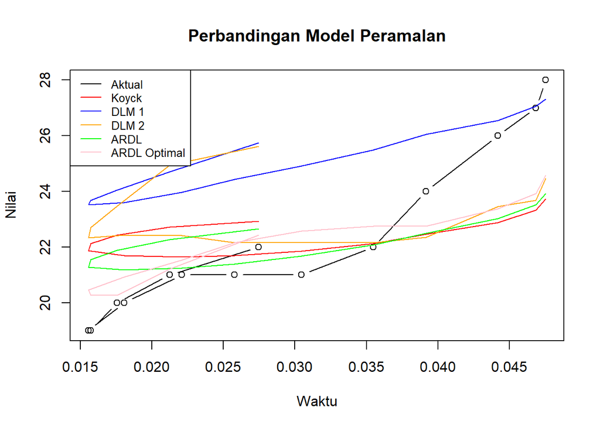

```r
par(mfrow=c(1,1))

# Plot data aktual TANPA ylim agar R menyesuaikan otomatis
plot(test$Xt, test$Yt, type="b", col="black",
     xlab="Waktu", ylab="Nilai", main="Perbandingan Model Peramalan") # Tambah label agar rapi

# Tambahkan garis ramalan dari masing-masing model
lines(test$Xt, fore.koyck$forecasts, col="red")
lines(test$Xt, fore.dlm$forecasts, col="blue")
lines(test$Xt, fore.dlm2$forecasts, col="orange")
lines(test$Xt, fore.ardl$forecasts, col="green")
lines(test$Xt, fore.ardl_opt$forecasts, col="pink")

# Legenda yang sudah diperbaiki (5 model, 5 warna)
legend("topleft",
       c("Aktual", "Koyck", "DLM 1", "DLM 2", "ARDL", "ARDL Optimal"), # Sesuaikan nama jika perlu
       lty=1, col=c("black", "red", "blue", "orange", "green", "pink"),
       cex=0.8)
```

# Perbandingan Model Regresi dengan Lag

Qaulan Sadiida Putri Sumarna (G1401231001)

2025-09-15

# Library

```r
library(readxl)
library(dLagM)
library(dynlm)
library(MLmetrics)
library(lmtest)
library(car)
```

# Import Data

```r
data <-read_excel("~/IPB Kuliah/Semester 5/MPDW/Pertemuan 3/excel_NewDelhi_Air_quality.xls")
str(data)
```

```
## tibble [72 × 4] (S3: tbl_df/tbl/data.frame)
##  $ t     : num [1:72] 1 2 3 4 5 6 7 8 9 10 ...
##  $ Yt    : chr [1:72] "30.2" "28.2" "26.6" "25" ...
##  $ Y(t-1): chr [1:72] NA "30.2" "28.2" "26.6" ...
##  $ Xt    : chr [1:72] "0.046857167" "0.046455536" "0.046857167" "0.048195943" ...
```

```r
data
```

```
## # A tibble: 72 × 4
##        t Yt    `Y(t-1)` Xt
##    <dbl> <chr> <chr>    <chr>
##  1     1 30.2  <NA>     0.046857167
##  2     2 28.2  30.2     0.046455536
##  3     3 26.6  28.2     0.046857167
##  4     4 25    26.6     0.048195943
##  5     5 26    25       0.048865333
##  6     6 26    26       0.050204106
##  7     7 26    26       0.050204106
##  8     8 24    26       0.050204106
##  9     9 23    24       0.046857167
## 10    10 24    23       0.044179615
## # ℹ 62 more rows
```

```r
data$Yt <- as.numeric(data$Yt)
data$Xt <- as.numeric(data$Xt)
```

```r
data
```

```
## # A tibble: 72 × 4
##        t    Yt `Y(t-1)`     Xt
##    <dbl> <dbl> <chr>     <dbl>
##  1     1  30.2 <NA>     0.0469
##  2     2  28.2 30.2     0.0465
##  3     3  26.6 28.2     0.0469
##  4     4  25   26.6     0.0482
##  5     5  26   25       0.0489
##  6     6  26   26       0.0502
##  7     7  26   26       0.0502
##  8     8  24   26       0.0502
##  9     9  23   24       0.0469
## 10    10  24   23       0.0442
## # ℹ 62 more rows
```

# Pembagian Data

Di sini data dibagi menjadi 2 bagian yaitu data train dan data test

```r
#SPLIT DATA
train<-data[1:58,]
test<-data[59:72,]
```

```r
#data time series
train.ts<-ts(train)
test.ts<-ts(test)
data.ts<-ts(data)
```

# Model Koyck

$$y_t=a(1-\lambda)+\beta_0X_t+\beta_1Z_t+\lambda Y_{t-1}+V_t$$
dengan
$$V_t=u_t-\lambda
u_{t-1}$$

## Pemodelan

```r
#MODEL KOYCK
model.koyck <- koyckDlm(x = train$Xt, y = train$Yt)
summary(model.koyck)
```

```
##
## Call:
## "Y ~ (Intercept) + Y.1 + X.t"
##
## Residuals:
##      Min       1Q   Median       3Q      Max
## -2.14846 -0.54834 -0.04671  0.55341  2.25964
##
## Coefficients:
##             Estimate Std. Error t value Pr(>|t|)
## (Intercept)  1.99147    1.58621   1.255    0.215
## Y.1          0.88020    0.06305  13.960   <2e-16 ***
## X.t         25.33442   18.07104   1.402    0.167
## ---
## Signif. codes:  0 '***' 0.001 '**' 0.01 '*' 0.05 '.' 0.1 ' ' 1
##
## Residual standard error: 0.936 on 54 degrees of freedom
## Multiple R-Squared: 0.8243,  Adjusted R-squared: 0.8178
## Wald test: 125.9 on 2 and 54 DF,  p-value: < 2.2e-16
##
## Diagnostic tests:
## NULL
##
##                             alpha     beta       phi
## Geometric coefficients:  16.62273 25.33442 0.8801961
```

```r
AIC(model.koyck)
```

```
## [1] 159.136
```

```r
BIC(model.koyck)
```

```
## [1] 167.3082
```

```r
fore.koyck <- forecast(model = model.koyck, x=test$Xt, h=14)
fore.koyck
```

```
## $forecasts
##  [1] 22.93128 22.71392 22.42934 22.13221 21.86644 21.69610 21.64792 21.69879
##  [9] 21.86227 22.13336 22.46524 22.88455 23.32146 23.72298
##
## $call
## forecast.koyckDlm(model = model.koyck, x = test$Xt, h = 14)
##
## attr(,"class")
## [1] "forecast.koyckDlm" "dLagM"
```

```r
mape.koyck <- MAPE(fore.koyck$forecasts, test$Yt)
mape.koyck #data test
```

```
## [1] 0.08785389
```

Berdasarkan nilai MAPE yang kurang dari 10% artinya tingkat akurasi peramalan sangat baik.

```r
#akurasi data training
GoF(model.koyck)
```

```
##              n       MAE          MPE       MAPE    sMAPE     MASE       MSE
## model.koyck 57 0.7025115 -0.001149676 0.02619192 0.026114 1.057544 0.8299675
##                  MRAE    GMRAE
## model.koyck 975249991 11827.09
```

## Kesimpulan

Model Koyck menunjukkan kinerja yang sangat baik dan andal untuk peramalan. Dengan nilai MAPE pada data test sebesar 8.8%, model ini terbukti memiliki kemampuan generalisasi yang kuat, di mana rata-rata kesalahan prediksi untuk data baru berada di bawah 10%. Meskipun nilai MAPE pada data train jauh lebih kecil (2.6%) yang mengindikasikan adanya sedikit gejala overfitting, akurasi yang tinggi pada data test menegaskan bahwa model ini tetap efektif dan dapat diandalkan untuk digunakan dalam peramalan di masa depan.

# Regression with Distribution Lag

```r
model.dlm <- dlm(x = train$Xt,y = train$Yt , q = 1)
summary(model.dlm)
```

```
##
## Call:
## lm(formula = model.formula, data = design)
##
## Residuals:
##    Min     1Q Median     3Q    Max
## -4.561 -1.200 -0.178  1.048  4.175
##
## Coefficients:
##             Estimate Std. Error t value Pr(>|t|)
## (Intercept)   21.626      1.524  14.195   <2e-16 ***
## x.t           38.229     78.565   0.487    0.629
## x.1           82.539     79.202   1.042    0.302
## ---
## Signif. codes:  0 '***' 0.001 '**' 0.01 '*' 0.05 '.' 0.1 ' ' 1
##
## Residual standard error: 2 on 54 degrees of freedom
## Multiple R-squared:  0.1973, Adjusted R-squared:  0.1676
## F-statistic: 6.636 on 2 and 54 DF,  p-value: 0.00265
##
## AIC and BIC values for the model:
##        AIC      BIC
## 1 245.7191 253.8913
```

```r
AIC(model.dlm)
```

```
## [1] 245.7191
```

```r
BIC(model.dlm)
```

```
## [1] 253.8913
```

### Peramalan dan Akurasi

```r
fore.dlm <- forecast(model = model.dlm, x=test$Xt, h=14)
fore.dlm
```

```
## $forecasts
##  [1] 25.74120 24.70335 24.05154 23.67729 23.51895 23.60110 23.96183 24.43408
##  [9] 24.91709 25.49578 26.05090 26.54671 27.06345 27.31005
##
## $call
## forecast.dlm(model = model.dlm, x = test$Xt, h = 14)
##
## attr(,"class")
## [1] "forecast.dlm" "dLagM"
```

```r
mape.dlm <- MAPE(fore.dlm$forecasts, test$Yt)
mape.dlm
```

```
## [1] 0.1426083
```

```r
#akurasi data training
GoF(model.dlm)
```

```
##            n      MAE          MPE       MAPE      sMAPE     MASE      MSE
## model.dlm 57 1.556814 -0.005088029 0.05738728 0.05712606 2.343592 3.791013
##                 MRAE    GMRAE
## model.dlm 6598415940 26698.16
```

## Pemodelan Lag Optimum

```r
#penentuan lag optimum
finiteDLMauto(formula = Yt ~ Xt,
              data = data.frame(train), q.min = 1, q.max = 10,
              model.type = "dlm", error.type = "AIC", trace = TRUE)
```

```
##    q - k    MASE      AIC      BIC    GMRAE    MBRAE R.Adj.Sq    Ljung-Box
## 10    10 1.86442 192.4265 216.7521 58000.45  1.08205  0.46425 7.786119e-07
## 9      9 1.96741 200.9250 223.6268 49014.18  0.70980  0.41910 2.996706e-07
## 8      8 2.08169 211.3028 232.3350 40397.08  4.04480  0.36542 1.654175e-07
## 7      7 2.18686 219.7987 239.1170 34340.25  1.76283  0.31099 1.947563e-08
## 6      6 2.16325 223.6641 241.2253 28976.64  2.26638  0.29359 3.377353e-09
## 5      5 2.18073 228.6285 244.3909 31773.29  2.77409  0.26048 1.905553e-09
## 4      4 2.21937 233.2316 247.1545 35199.94 12.84165  0.23155 5.861548e-10
## 3      3 2.28713 237.6810 249.7250 32757.45  1.08578  0.21352 2.364642e-10
## 2      2 2.24909 239.9943 250.1210 28850.15  1.01775  0.21346 1.492265e-10
## 1      1 2.34359 245.7191 253.8913 26698.16  0.45855  0.16755 4.335832e-11
```

```r
#model dlm dengan lag optimum
model.dlm2 <- dlm(x = train$Xt,y = train$Yt , q = 10)
summary(model.dlm2)
```

```
##
## Call:
## lm(formula = model.formula, data = design)
##
## Residuals:
##     Min      1Q  Median      3Q     Max
## -3.2054 -0.8089  0.1479  0.7155  2.6768
##
## Coefficients:
##             Estimate Std. Error t value Pr(>|t|)
## (Intercept)    13.70       2.21   6.199 3.77e-07 ***
## x.t           220.92      99.97   2.210   0.0336 *
## x.1          -236.52     217.99  -1.085   0.2851
## x.2           220.05     269.77   0.816   0.4200
## x.3           -22.48     279.87  -0.080   0.9364
## x.4            29.92     283.60   0.105   0.9166
## x.5           -49.87     283.18  -0.176   0.8612
## x.6            68.49     282.75   0.242   0.8100
## x.7           -16.28     280.16  -0.058   0.9540
## x.8            48.78     270.12   0.181   0.8577
## x.9            56.65     225.14   0.252   0.8028
## x.10          -13.43     107.20  -0.125   0.9010
## ---
## Signif. codes:  0 '***' 0.001 '**' 0.01 '*' 0.05 '.' 0.1 ' ' 1
##
## Residual standard error: 1.582 on 36 degrees of freedom
## Multiple R-squared:  0.5896, Adjusted R-squared:  0.4642
## F-statistic: 4.702 on 11 and 36 DF,  p-value: 0.0001919
##
## AIC and BIC values for the model:
##        AIC      BIC
## 1 192.4265 216.7521
```

Dari hasil tersebut terdapat beberapa peubah yang berpengaruh signifikan terhadap taraf nyata 5% yaitu $x_t$. Adapun keseluruhan model yang terbentuk adalah:

$$\hat{Y_t}=13.70+220.92X_t+...-13.43X_{t-10}$$

```r
AIC(model.dlm2)
```

```
## [1] 192.4265
```

```r
BIC(model.dlm2)
```

```
## [1] 216.7521
```

### Peramalan dan Akurasi

```r
#peramalan dan akurasi
fore.dlm2 <- forecast(model = model.dlm2, x=test$Xt, h=14)

#akurasi data test
mape.dlm2<- MAPE(fore.dlm2$forecasts, test$Yt)
mape.dlm2
```

```
## [1] 0.1156261
```

```r
#akurasi data training
GoF(model.dlm2)
```

```
##             n     MAE          MPE      MAPE      sMAPE     MASE      MSE
## model.dlm2 48 1.11072 -0.002504083 0.0408604 0.04067712 1.864423 1.876373
##                  MRAE    GMRAE
## model.dlm2 5382224296 58000.45
```

### Kesimpulan

Meskipun model ini menunjukkan kecocokan yang sangat tinggi dengan data latih, yang dibuktikan oleh nilai MAPE train sebesar 4%, kinerjanya pada data baru menunjukkan adanya masalah. Dengan nilai MAPE test sebesar 11%, rata-rata kesalahan prediksi pada data yang belum pernah dilihat adalah 11%, yang berada di ambang batas akurasi yang dapat diterima. Perbedaan yang cukup signifikan antara MAPE train dan test ini mengindikasikan adanya gejala overfitting, di mana model terlalu “menghafal” pola data latih sehingga kurang mampu menggeneralisasi dengan baik pada data baru. Oleh karena itu, walaupun model ini tampak sempurna pada data latih, keandalannya untuk peramalan di dunia nyata perlu diwaspadai karena akurasinya cenderung menurun.

# Model Autoregressive

## Pemodelan

```r
model.ardl <- ardlDlm(formula = Yt ~ Xt, data = train, p = 1, q = 1)
summary(model.ardl)
```

```
##
## Time series regression with "ts" data:
## Start = 2, End = 58
##
## Call:
## dynlm(formula = as.formula(model.text), data = data)
##
## Residuals:
##      Min       1Q   Median       3Q      Max
## -2.16166 -0.58232 -0.06645  0.65582  2.30185
##
## Coefficients:
##              Estimate Std. Error t value Pr(>|t|)
## (Intercept)   1.86844    1.59710   1.170    0.247
## Xt.t         52.28983   36.93442   1.416    0.163
## Xt.1        -24.90414   38.02127  -0.655    0.515
## Yt.1          0.88147    0.06369  13.839   <2e-16 ***
## ---
## Signif. codes:  0 '***' 0.001 '**' 0.01 '*' 0.05 '.' 0.1 ' ' 1
##
## Residual standard error: 0.9401 on 53 degrees of freedom
## Multiple R-squared:  0.826,  Adjusted R-squared:  0.8162
## F-statistic: 83.87 on 3 and 53 DF,  p-value: < 2.2e-16
```

```r
AIC(model.ardl)
```

```
## [1] 160.566
```

```r
BIC(model.ardl)
```

```
## [1] 170.7813
```

### Peramalan dan Akurasi

```r
fore.ardl <- forecast(model = model.ardl, x=test$Xt, h=14)
fore.ardl
```

```
## $forecasts
##  [1] 22.65223 22.26364 21.88279 21.54252 21.27966 21.18339 21.24603 21.39374
##  [9] 21.67726 22.07300 22.48932 23.02713 23.51617 23.91556
##
## $call
## forecast.ardlDlm(model = model.ardl, x = test$Xt, h = 14)
##
## attr(,"class")
## [1] "forecast.ardlDlm" "dLagM"
```

Data di atas merupakan hasil peramalan untuk 14 periode ke depan menggunakan Model Autoregressive dengan $p=1$ dan $q=1$.

```r
mape.ardl <- MAPE(fore.ardl$forecasts, test$Yt)
mape.ardl
```

```
## [1] 0.07251087
```

```r
#akurasi data training
GoF(model.ardl)
```

```
##             n       MAE          MPE       MAPE      sMAPE    MASE       MSE
## model.ardl 57 0.7000972 -0.001125164 0.02607232 0.02600883 1.05391 0.8217096
##                  MRAE    GMRAE
## model.ardl 1052979631 10713.28
```

## Pemodelan Lag Optimum

```r
#penentuan lag optimum
model.ardl.opt <- ardlBoundOrders(data = data.frame(data), ic = "AIC",
                                  formula = Yt ~ Xt )
model.ardl.opt
```

```
## $p
##   Xt
## 1 14
##
## $q
## [1] 6
##
## $Stat.table
##           q = 1    q = 2    q = 3    q = 4    q = 5    q = 6    q = 7    q = 8
## p = 1  170.3093 168.2296 167.6630 162.0153 161.7109 161.5980 149.3522 146.1330
## p = 2  170.5026 170.1847 169.6265 163.9985 163.6997 163.5845 151.3479 148.1279
## p = 3  168.9545 168.9545 170.8939 164.8176 164.3950 164.4204 151.2064 148.4276
## p = 4  163.2621 165.0565 165.0565 164.5713 163.4460 163.6274 150.1745 146.6553
## p = 5  161.4664 163.3504 164.9035 164.9035 164.7271 165.1742 151.2301 147.5395
## p = 6  160.3708 162.0587 163.6798 165.6617 165.6617 167.1342 153.2168 149.5388
## p = 7  153.4558 152.5951 152.5232 154.1874 153.2414 153.2414 154.8761 150.7382
## p = 8  153.4455 151.3524 149.7374 149.6292 150.0472 150.4866 150.4866 150.3079
## p = 9  153.6218 149.2655 148.0769 148.3268 149.6437 150.3936 151.4737 151.4737
## p = 10 154.3237 148.9806 147.0992 147.7813 149.6134 147.8170 149.3216 151.2587
## p = 11 152.8246 147.2700 143.3876 143.5410 145.3635 141.4386 143.3955 145.3526
## p = 12 150.3625 146.0378 141.9794 141.5993 143.3358 140.8954 142.8918 144.8879
## p = 13 143.6580 141.4498 139.4298 140.3735 141.7075 140.6131 142.5246 144.0408
## p = 14 141.0952 138.1586 135.8735 135.2894 135.4155 133.8784 134.8962 136.8393
## p = 15 140.0990 138.3277 136.7005 136.0430 135.8393 134.8602 135.6501 137.4812
##           q = 9   q = 10   q = 11   q = 12   q = 13   q = 14   q = 15
## p = 1  146.1298 144.9969 142.7437 143.8445 141.1766 140.7567 141.3347
## p = 2  148.0970 146.9908 144.7166 145.8205 142.7848 142.5564 143.1800
## p = 3  148.9095 146.8432 144.9040 146.0171 143.5744 142.5727 142.8625
## p = 4  147.3242 146.3531 142.4633 143.4331 142.6414 140.3770 141.0852
## p = 5  148.3806 147.4864 144.0258 144.9613 144.3698 141.7517 142.3290
## p = 6  150.3806 149.4610 145.9726 146.9217 146.3002 143.7375 144.2802
## p = 7  151.5005 150.4157 146.8102 147.7818 146.8707 144.7648 145.2291
## p = 8  150.7515 148.9649 144.6154 145.8839 144.9476 143.2089 144.5887
## p = 9  152.7515 150.9227 146.3763 147.5882 145.9946 144.2941 145.6934
## p = 10 151.2587 151.8250 147.9225 149.2113 147.9085 145.6151 146.9836
## p = 11 146.8958 146.8958 144.0794 145.5575 145.2422 140.1257 141.2658
## p = 12 145.0783 145.2027 145.2027 147.2026 146.6909 140.2069 140.4075
## p = 13 145.7825 147.2814 147.7678 147.7678 148.6901 142.1545 142.4042
## p = 14 138.4910 139.3013 136.9173 138.4174 138.4174 139.7855 140.3840
## p = 15 138.6672 137.5998 137.8855 139.7993 140.2816 140.2816 142.2603
##
## $min.Stat
## [1] 133.8784
```

```r
min_p=c()
for(i in 1:6){
  min_p[i]=min(model.ardl.opt$Stat.table[[i]])
}
q_opt=which(min_p==min(min_p, na.rm = TRUE))
p_opt=which(model.ardl.opt$Stat.table[[q_opt]] ==
              min(model.ardl.opt$Stat.table[[q_opt]], na.rm = TRUE))
data.frame("q_optimum" = q_opt, "p_optimum" = p_opt,
           "AIC"=model.ardl.opt$min.Stat)
```

```
##   q_optimum p_optimum      AIC
## 1         6        14 133.8784
```

Selanjutnya dapat dilakukan pemodelan dengan nilai $p$ dan $q$ optimum seperti inisialisasi di langkah sebelumnya.

```r
model.ardl_opt <- ardlDlm(formula = Yt ~ Xt,
                         data = train,p = 14 , q = 6)
summary(model.ardl_opt)
```

```
##
## Time series regression with "ts" data:
## Start = 15, End = 58
##
## Call:
## dynlm(formula = as.formula(model.text), data = data)
##
## Residuals:
##      Min       1Q   Median       3Q      Max
## -1.60883 -0.37338 -0.04104  0.38738  1.13873
##
## Coefficients:
##              Estimate Std. Error t value Pr(>|t|)
## (Intercept)   3.19377    3.17090   1.007  0.32478
## Xt.t         96.16559   53.89112   1.784  0.08815 .
## Xt.1        -95.71199  110.89255  -0.863  0.39739
## Xt.2        102.99425  135.05686   0.763  0.45380
## Xt.3        -36.97741  142.31942  -0.260  0.79742
## Xt.4        -46.87238  144.98914  -0.323  0.74953
## Xt.5         20.13826  145.72374   0.138  0.89134
## Xt.6         41.11402  147.70689   0.278  0.78334
## Xt.7         11.55093  149.77397   0.077  0.93922
## Xt.8         18.11858  147.37077   0.123  0.90327
## Xt.9        -20.54254  144.26057  -0.142  0.88806
## Xt.10        48.25942  144.84287   0.333  0.74215
## Xt.11       -61.85911  142.93389  -0.433  0.66939
## Xt.12        21.51505  137.21322   0.157  0.87683
## Xt.13       -34.40043  117.87067  -0.292  0.77314
## Xt.14        61.00690   60.98943   1.000  0.32805
## Yt.1          0.80575    0.24949   3.230  0.00385 **
## Yt.2          0.26143    0.28877   0.905  0.37511
## Yt.3          0.02459    0.27882   0.088  0.93052
## Yt.4         -0.36573    0.27783  -1.316  0.20160
## Yt.5         -0.15145    0.30088  -0.503  0.61971
## Yt.6          0.10230    0.21868   0.468  0.64453
## ---
## Signif. codes:  0 '***' 0.001 '**' 0.01 '*' 0.05 '.' 0.1 ' ' 1
##
## Residual standard error: 0.7498 on 22 degrees of freedom
## Multiple R-squared:  0.9408, Adjusted R-squared:  0.8843
## F-statistic: 16.65 on 21 and 22 DF,  p-value: 4.517e-09
```

```r
AIC(model.ardl_opt)
```

```
## [1] 115.025
```

```r
BIC(model.ardl_opt)
```

```
## [1] 156.0614
```

### Peramalan dan Akurasi

```r
fore.ardl_opt <- forecast(model = model.ardl_opt, x=test$Xt, h=14)
fore.ardl_opt
```

```
## $forecasts
##  [1] 22.42503 21.21397 20.26295 20.27269 20.46057 20.93085 21.53321 22.16080
##  [9] 22.57768 22.75177 22.75485 23.37970 23.91815 24.57671
##
## $call
## forecast.ardlDlm(model = model.ardl_opt, x = test$Xt, h = 14)
##
## attr(,"class")
## [1] "forecast.ardlDlm" "dLagM"
```

```r
mape.ardl_opt <- MAPE(fore.ardl_opt$forecasts, test$Yt)
mape.ardl_opt
```

```
## [1] 0.05800608
```

```r
#akurasi data training
GoF(model.ardl_opt)
```

```
##                 n       MAE           MPE       MAPE      sMAPE      MASE
## model.ardl_opt 44 0.4277857 -0.0003975484 0.01577056 0.01574953 0.7664494
##                      MSE       MRAE    GMRAE
## model.ardl_opt 0.2810769 1721348484 39053.97
```

### Kesimpulan

Karena nilai MAPE untuk data train dan data test sama-sama dibawah 10% maka disimpulkan bahwa model dapat memelajari data dengan baik.

# Perbandingan Model dengan MAPE

```r
akurasi <- matrix(c(mape.koyck, mape.dlm, mape.dlm2, mape.ardl, mape.ardl_opt))
row.names(akurasi)<- c("Koyck","DLM 1","DLM 2","Autoregressive", "Autoregressive 2")
colnames(akurasi) <- c("MAPE")
akurasi
```

```
##                        MAPE
## Koyck            0.08785389
## DLM 1            0.14260835
## DLM 2            0.11562613
## Autoregressive   0.07251087
## Autoregressive 2 0.05800608
```

Berdasarkan nilai MAPE, model paling optimum didapat pada Model Autoregressive 2 yaitu yang menggunakan lag optimum karena memiliki nilai MAPE yang terkecil.

# Plot

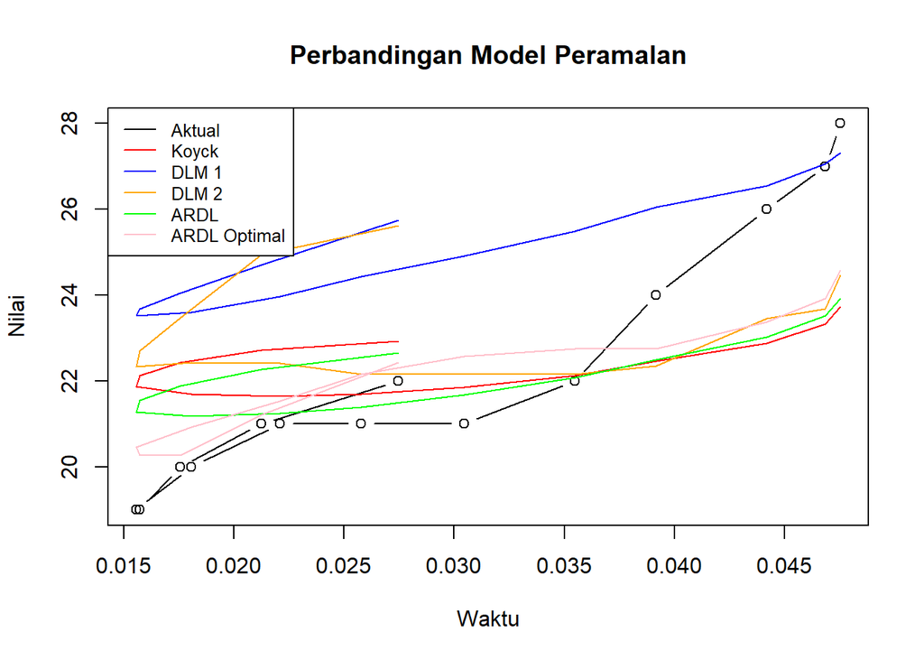

```r
par(mfrow=c(1,1))

# Plot data aktual TANPA ylim agar R menyesuaikan otomatis
plot(test$Xt, test$Yt, type="b", col="black",
     xlab="Waktu", ylab="Nilai", main="Perbandingan Model Peramalan") # Tambah label agar rapi

# Tambahkan garis ramalan dari masing-masing model
lines(test$Xt, fore.koyck$forecasts, col="red")
lines(test$Xt, fore.dlm$forecasts, col="blue")
lines(test$Xt, fore.dlm2$forecasts, col="orange")
lines(test$Xt, fore.ardl$forecasts, col="green")
lines(test$Xt, fore.ardl_opt$forecasts, col="pink")

# Legenda yang sudah diperbaiki (5 model, 5 warna)
legend("topleft",
       c("Aktual", "Koyck", "DLM 1", "DLM 2", "ARDL", "ARDL Optimal"), # Sesuaikan nama jika perlu
       lty=1, col=c("black", "red", "blue", "orange", "green", "pink"),
       cex=0.8)
```